# Chapter3

Nate

12/17/2018

```r
knitr::opts_chunk$set(comment = NA, message=F, warning=F)
library(faraway)
library(skimr)
library(tidyverse)
```

# 1.

For the `prostate` data, fit a model with `lpsa` as the response and the other variables as predictors:

##a. Compute 90 and 95% CIs for the parameter associated with `age`. Using just these intervals what could we have deduced about the p-value for age in the regression summary?

```r
data(prostate) # from library(faraway)

m <- lm(lpsa ~ ., data = prostate)
sumary(m)
```

```
              Estimate Std. Error t value  Pr(>|t|)
(Intercept)  0.6693367  1.2963875  0.5163  0.606934
lcavol       0.5870218  0.0879203  6.6767 2.111e-09
lweight      0.4544674  0.1700124  2.6731  0.008955
age         -0.0196372  0.0111727 -1.7576  0.082293
lbph         0.1070540  0.0584492  1.8316  0.070398
svi          0.7661573  0.2443091  3.1360  0.002329
lcp         -0.1054743  0.0910135 -1.1589  0.249638
gleason      0.0451416  0.1574645  0.2867  0.775033
pgg45        0.0045252  0.0044212  1.0235  0.308860

n = 97, p = 9, Residual SE = 0.70842, R-Squared = 0.65
```

```r
confint(m, c("age")) # .95 is default
```

```
          2.5 %      97.5 %
age -0.04184062 0.002566267
```

```r
confint(m, c("age"), .90)
```

```
           5 %         95 %
age -0.0382102 -0.001064151
```

Based on the confidence intervals `age` is on the border for being considered significant. Because the 90% CI doesn’t include 0, `age` is signficant at that level, but the upper bound of the more stringent 95% CI stretches just over zero to 0.0025. The regression sumamry confirms this by returning a p-value of 0.08, close but above the common 0.05 threshold for significance.

## b.

Compute and display a 95% joint confidence region for the parameters associated with `age` and `lbph`. Plot the origin on this display. The location of the origin on the display tells us the outcome for a certain hypothesis test. State that test and its outcome.

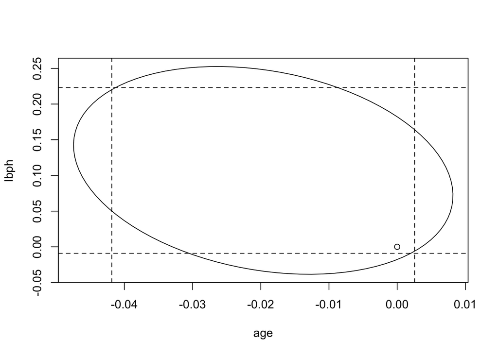

```r
library(ellipse)
plot(ellipse(m, c('age', 'lbph')), type = "l")
points(0, 0, pch = 1)
abline(v= confint(m)['age',], lty = 2)
abline(h= confint(m)['lbph',], lty = 2)
```

The joint null hypothesis `age = lbph = 0`, can not be rejected because the origin lies inside of the confidence region ellipse. Similarly the null hypothesis `age = 0` can not be rejected becasue 0 lies with the 95% confidence bounds and the same is true for the null hypothesis `lbph = 0`.

## c.

In the text, we made a permutation test corresponding to the F-test for the significant of all the predictors. Execute the permutation test corresponding to the t-test for age in the model. (Hint: `summary(g)$coef[4,3]` gets your the t-statistic you need if the model is called `g`)

```r
t_value <- summary(m) %>% coef() %>% .['age', 't value']

# function to permutate n-times
permute_tmod <- function(nsims) {
    map_dbl(1:nsims,
            ~ update(m, . ~ . - age + sample(age)) %>%
            summary() %>%
            coef() %>%
            .['sample(age)', 't value'])
}

mean(abs(permute_tmod(100)) > abs(t_value))
```

```
[1] 0.09
```

```r
mean(abs(permute_tmod(1000)) > abs(t_value))
```

```
[1] 0.086
```

```r
mean(abs(permute_tmod(10000)) > abs(t_value))
```

```
[1] 0.0793
```

From section `a` above we know the p-value for `age` is 0.08229, and we can see the return value from the permutation getting closer to that number as the number of simulations increases.

## d.

Remove all the predictors that are not significant at the 5% level. Test this model against the original model. Which model is preffered?

```r
m2 <- update(m, . ~ lcavol + lweight + svi)

anova(m, m2)
```

```
Analysis of Variance Table

Model 1: lpsa ~ lcavol + lweight + age + lbph + svi + lcp + gleason +
    pgg45
Model 2: lpsa ~ lcavol + lweight + svi
  Res.Df    RSS Df Sum of Sq      F Pr(>F)
1     88 44.163
2     93 47.785 -5   -3.6218 1.4434 0.2167
```

# 2.

```r
data("cheddar")
skim(cheddar)
```

Data summary

| Name | cheddar |
| --- | --- |
| Number of rows | 30 |
| Number of columns | 4 |
| _______________________ |  |
| Column type frequency: |  |
| numeric | 4 |
| ________________________ |  |
| Group variables | None |

**Variable type: numeric**

| skim_variable | n_missing | complete_rate | mean | sd | p0 | p25 | p50 | p75 | p100 | hist |
| --- | --- | --- | --- | --- | --- | --- | --- | --- | --- | --- |
| taste | 0 | 1 | 24.53 | 16.26 | 0.70 | 13.55 | 20.95 | 36.70 | 57.20 | ▅▇▃▃▃ |
| Acetic | 0 | 1 | 5.50 | 0.57 | 4.48 | 5.24 | 5.42 | 5.88 | 6.46 | ▆▆▇▇▇ |
| H2S | 0 | 1 | 5.94 | 2.13 | 3.00 | 3.98 | 5.33 | 7.57 | 10.20 | ▇▆▅▅▃ |
| Lactic | 0 | 1 | 1.44 | 0.30 | 0.86 | 1.25 | 1.45 | 1.67 | 2.01 | ▃▇▅▅▅ |

## a.

```r
m <- lm(taste ~ ., cheddar)
sumary(m)
```

```
             Estimate Std. Error t value Pr(>|t|)
(Intercept) -28.87677   19.73542 -1.4632 0.155399
Acetic        0.32774    4.45976  0.0735 0.941980
H2S           3.91184    1.24843  3.1334 0.004247
Lactic       19.67054    8.62905  2.2796 0.031079

n = 30, p = 4, Residual SE = 10.13071, R-Squared = 0.65
```

Hydrogen sulfide (H2S) and lactic acid (Lactic) are both signifcant at the 5% level.

## b.

```r
m2 <- lm(taste ~ exp(H2S) + exp(Acetic) + Lactic, cheddar)
sumary(m2)
```

```
               Estimate  Std. Error t value Pr(>|t|)
(Intercept) -1.8973e+01  1.1268e+01 -1.6838  0.10420
exp(H2S)     7.6684e-04  4.1878e-04  1.8311  0.07857
exp(Acetic)  1.8906e-02  1.5623e-02  1.2101  0.23711
Lactic       2.5007e+01  9.0621e+00  2.7595  0.01046

n = 30, p = 4, Residual SE = 11.18654, R-Squared = 0.58
```

## c.

```r
anova(m, m2)
```

```
Analysis of Variance Table

Model 1: taste ~ Acetic + H2S + Lactic
Model 2: taste ~ exp(H2S) + exp(Acetic) + Lactic
  Res.Df    RSS Df Sum of Sq F Pr(>F)
1     26 2668.4
2     26 3253.6  0    -585.2
```

Using an F-test here doesn’t make sense because the models being compared are not nested. They do contain the same predictor variables, but because of the transformations they are different values.

R is smart and doesn’t even report an F statistic to help us stay out of trouble. Based on the residual error, we’d prefer `m` with the logged predictors.

## d.

```r
summary(m) %>% coef() %>% .["H2S", "Estimate"] %>% {. * 0.01}
```

```
[1] 0.03911841
```

Taste score would increase by 0.039, not a long cosider the range is 0.7, 57.2

## e.

```r
(exp(.01) - 1) %>% scales::percent()
```

```
[1] "1%"
```